# Mental Health Treatment Prediction in the Workplace

Preparation 1 & 2: Data Preprocessing and Modeling Plan

Richel Attafuah

April 2026

## 1. Data Overview & Source

The dataset used in this project is the **OSMI Mental Health in Tech Survey (2014)**, collected by Open Sourcing Mental Illness (OSMI), a non-profit organization dedicated to raising awareness and providing resources for mental health in the tech community. The survey was administered online and captures responses from tech workers across 60+ countries on workplace mental health culture, employer support, and personal mental health history.

**Source:** [OSMI Mental Health in Tech Survey — Kaggle](https://www.kaggle.com/datasets/osmi/mental-health-in-tech-survey)

## 2. Response Variable Identification

The response variable for this project is **`treatment`** , a binary variable indicating whether a tech worker has sought mental health treatment (Yes/No). This is a **Classification** problem. The goal is to predict the probability that a tech worker seeks mental health treatment based on workplace environment, employee support policies, and personal background factors.

Response variable distribution

| Sought Treatment | Count | Proportion |
| --- | --- | --- |
| No | 622 | 0.494 |
| Yes | 637 | 0.506 |

## 3. Preliminary Exploratory Data Analysis (EDA)

### 3.1 Dataset Structure

Dataset structure summary

| total_variables | numeric_vars | character_vars | datetime_vars |
| --- | --- | --- | --- |
| 27 | 1 | 25 | 1 |

### 3.2 Variable Types

### 3.2.1 Variable Descriptions

The OSMI Mental Health in Tech Survey captures a rich set of workplace, organizational, and personal factors that may influence whether a tech worker seeks mental health treatment. The dataset contains one continuous numeric predictor (Age), one engineered categorical predictor (Gender), and 21 additional categorical predictors covering employer policies, workplace culture, and personal mental health history. The response variable, `treatment`, is a binary indicator of whether the respondent has ever sought professional mental health treatment. Understanding each variable is essential before modeling, several predictors capture closely related constructs (e.g. `mental_health_consequence` and `obs_consequence`) that may exhibit multicollinearity, and ordered categorical variables such as `work_interfere` and `leave` will require special attention during feature engineering to preserve their natural ordering.

Data dictionary — full variable inventory with descriptions

| Variable | Role | Type | Description |
| --- | --- | --- | --- |
| treatment | Response | Binary factor | Whether the respondent has ever sought professional mental health treatment (Yes / No) |
| Age | Predictor | Numeric (continuous) | Age of the respondent in years. Cleaned to retain only plausible values between 18 and 75 |
| Gender | Predictor | Categorical factor (3 levels) | Gender identity of the respondent. Raw entries were standardized into three categories: Male, Female, and Other |
| Country | Predictor | Categorical factor | Country of residence or employment of the respondent |
| self_employed | Predictor | Binary factor | Whether the respondent is self-employed (Yes / No) |
| family_history | Predictor | Binary factor | Whether the respondent has a family history of mental illness (Yes / No) |
| work_interfere | Predictor | Ordinal factor (4 levels) | How often mental health conditions interfere with work when untreated (Never / Rarely / Sometimes / Often) |
| no_employees | Predictor | Ordinal factor (6 levels) | Number of employees at the respondent’s company (1–5 / 6–25 / 26–100 / 100–500 / 500–1000 / More than 1000) |
| remote_work | Predictor | Binary factor | Whether the respondent works remotely at least 50% of the time (Yes / No) |
| tech_company | Predictor | Binary factor | Whether the respondent’s employer is primarily a tech company or organization (Yes / No) |
| benefits | Predictor | Categorical factor (3 levels) | Whether the employer provides mental health benefits as part of health coverage (Yes / No / Don’t know) |
| care_options | Predictor | Categorical factor (3 levels) | Whether the respondent is aware of mental health care options provided by their employer (Yes / No / Not sure) |
| wellness_program | Predictor | Categorical factor (3 levels) | Whether the employer has formally discussed mental health as part of a wellness program (Yes / No / Don’t know) |
| seek_help | Predictor | Categorical factor (3 levels) | Whether the employer provides resources to learn about mental health issues and how to seek help (Yes / No / Don’t know) |
| anonymity | Predictor | Categorical factor (3 levels) | Whether anonymity is protected if the respondent chooses to use mental health or substance abuse treatment resources (Yes / No / Don’t know) |
| leave | Predictor | Ordinal factor (5 levels) | How easy it is to take medical leave for a mental health condition (Very easy / Somewhat easy / Don’t know / Somewhat difficult / Very difficult) |
| mental_health_consequence | Predictor | Categorical factor (3 levels) | Whether the respondent believes discussing a mental health issue with their employer would have negative consequences (Yes / No / Maybe) |
| phys_health_consequence | Predictor | Categorical factor (3 levels) | Whether the respondent believes discussing a physical health issue with their employer would have negative consequences (Yes / No / Maybe) |
| coworkers | Predictor | Categorical factor (3 levels) | Whether the respondent would be comfortable discussing a mental health issue with their coworkers (Yes / No / Some of them) |
| supervisor | Predictor | Categorical factor (3 levels) | Whether the respondent would be comfortable discussing a mental health issue with their direct supervisor (Yes / No / Some of them) |
| mental_health_interview | Predictor | Categorical factor (3 levels) | Whether the respondent would bring up a mental health issue in a job interview (Yes / No / Maybe) |
| phys_health_interview | Predictor | Categorical factor (3 levels) | Whether the respondent would bring up a physical health issue in a job interview (Yes / No / Maybe) |
| mental_vs_physical | Predictor | Categorical factor (3 levels) | Whether the respondent feels their employer takes mental health as seriously as physical health (Yes / No / Don’t know) |
| obs_consequence | Predictor | Binary factor | Whether the respondent has heard of or observed negative consequences for coworkers who disclosed mental health issues (Yes / No) |

### 3.3 Response Variable Distribution

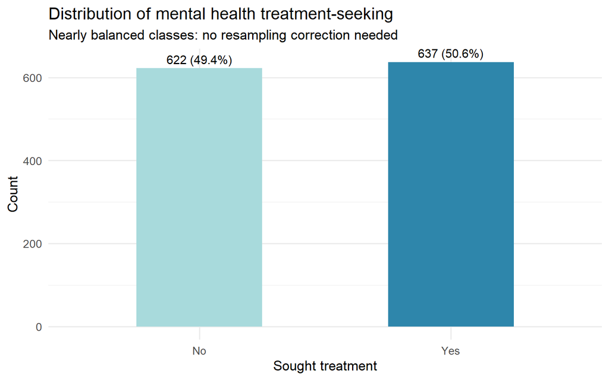

The response variable `treatment` is remarkably well-balanced, with **637 respondents (50.6%)** reporting that they have sought mental health treatment and **622 (49.4%)** reporting that they have not. This near-perfect class balance is a favorable property for classification modeling ,it means that a naive classifier that predicts the majority class every time would achieve only around 50% accuracy, giving our models a meaningful benchmark to surpass. Crucially, it also means that standard evaluation metrics such as accuracy are not misleading here, and no resampling corrections such as SMOTE or class weighting will be necessary. The balance also carries a substantive interpretation: mental health treatment-seeking is not a rare behavior in the tech workforce. Roughly half of survey respondents have sought professional help at some point, suggesting that the barriers to treatment are not insurmountable, but that meaningful variation exists in who chooses to seek help. This is precisely what makes the prediction task interesting and the resulting model actionable for employers and HR teams designing targeted mental health programs.

### 3.4 Missing Data Overview

Missing data by variable

| Variable | Missing | Pct_Missing |
| --- | --- | --- |
| comments | 1096 | 87.1 |
| state | 515 | 40.9 |
| work_interfere | 264 | 21.0 |
| self_employed | 18 | 1.4 |

Only four variables in the dataset contained missing values, and the pattern of missingness is both interpretable and manageable. The `comments` field, which captured open-ended free-text responses, was missing for **87.1% of respondents** this is entirely expected, as open-ended fields are rarely completed in voluntary surveys and carry no predictive value in a structured modeling context. It has been dropped from the analysis entirely. Similarly, `state` was missing for **40.9%** of respondents, largely because the question was only applicable to those based in the United States, retaining it would introduce substantial bias and noise, and it has likewise been removed.

The remaining two variables with missing data present no serious concern.`work_interfere` one of the most substantively important predictors in this dataset, capturing how frequently mental health conditions interfere with work, was missing for **21.0%** of respondents. Rather than discard these observations or the variable itself, missing values were imputed using the mode of the observed responses, preserving the full sample size and retaining this critical predictor. `self_employed` was missing for just **1.4%** of respondents and was handled identically.

Importantly, after applying these targeted remediation strategies, **zero missing values remain** across all 24 variables in the cleaned dataset. The decision to impute rather than drop reflects a deliberate effort to retain as many observations as possible for modeling, particularly given that the original sample of 1,259 respondents is already modest in size.

## 4. Initial Preprocessing & Cleaning

### 4.1 Drop non-informative variables

Before modeling can begin, three variables were removed from the dataset entirely. `Timestamp` records the date and time the survey was submitted and carries no information about a respondent’s likelihood of seeking mental health treatment. `state` was retained in the raw data long enough to assess its missingness, which at 40.9% was too severe to recover through imputation. `comments` was a free-text field left blank by 87.1% of respondents, and even where populated, unstructured text cannot be used directly in the models planned for this project. Removing these three columns reduces the variable count from 27 to 24, leaving a clean set of 23 predictors and one response variable.

### 4.2 Clean the Gender variable

Gender distribution after cleaning

| Gender | Count |
| --- | --- |
| Female | 246 |
| Male | 987 |
| Other | 26 |

### 4.3 Fix Age outliers

The `Age` variable contained severely implausible values prior to cleaning. The table below shows the distributional summary before and after restricting the variable to the plausible working-age range of 18 to 75 years.

Age variable summary — before and after outlier removal

| Stage | Min | Q1 | Median | Mean | Q3 | Max |
| --- | --- | --- | --- | --- | --- | --- |
| Before cleaning | -1726 | 27 | 31 | 79428148.3 | 36 | 1.0e+11 |
| After cleaning | 18 | 27 | 31 | 32.1 | 36 | 7.2e+01 |

The before-cleaning row reveals a minimum age of **−1,726** and a maximum exceeding **100 billion** , clear data entry errors with no plausible real-world interpretation. After filtering to ages 18–75, only **8 observations** were removed, and the core distribution remained virtually unchanged, confirming these were isolated anomalies rather than a systemic data quality issue.

### 4.6 Final cleaned dataset summary

Final cleaned dataset summary

| Observations | Predictors | Numeric vars | Factor vars |
| --- | --- | --- | --- |
| 1251 | 23 | 1 | 23 |

## 5. Next Steps

### 5.1 Modeling Strategy

Having established a clean, well-structured dataset of **1,251 observations** across **23 predictors**, this project will proceed to the full predictive modeling pipeline. All subsequent modeling will be performed on `survey_clean.csv` to ensure a fully reproducible workflow.

The central modeling question is:

> *Can we accurately predict whether a tech worker will seek mental health treatment based on their workplace environment, employer policies, and personal background?*

### 5.2 Macro/Micro Resampling Framework

Following the two-stage resampling methodology introduced in Lecture 4, the data will be partitioned into a **macro holdout test set** (held out entirely until final evaluation) and a **micro training set** on which all model development, cross-validation, and hyperparameter tuning will be conducted. This approach ensures that our final performance estimates are honest and generalizable, the test set will never influence any modeling decision.

### 5.4 Evaluation Framework

All models will be evaluated on the held-out macro test set using four metrics reported together: **AUC-ROC**, **Accuracy**, **Sensitivity**,and **Specificity**. AUC-ROC will serve as the primary model selection criterion, as it evaluates performance across all classification thresholds rather than at a single cutoff.

**Sensitivity** is given particular importance in this context. In a mental health setting, failing to identify an individual who would benefit from treatment, a false negative carries a higher real-world cost than an unnecessary positive flag. A model that maximizes sensitivity ensures fewer at-risk individuals are missed.

## 6. Model Selection & Justification

This project investigates a **binary classification problem**, predicting whether a tech worker seeks mental health treatment (Yes/No), using a dataset of 1,251 observations and 23 predictors, of which 22 are categorical and one is continuous. Four model types were selected to represent a deliberately diverse range of statistical learning approaches, spanning interpretable parametric models, regularized regression, and both single and ensemble tree-based methods. Each model was chosen not only for its methodological distinctiveness but for its specific suitability to the structure of this dataset.

### 6.1 Logistic Regression

Logistic regression is the natural starting point for any binary classification problem. As a generalized linear model, it estimates the log-odds of treatment-seeking as a linear combination of the predictors, producing output that is directly interpretable as probability. Its greatest strength in this context is transparency,each coefficient carries a clear and communicable meaning, which matters in a healthcare setting where stakeholders need to understand not just what the model predicts, but why. Logistic regression also serves an important methodological role as the **performance baseline**. If more complex models cannot meaningfully outperform a well-fitted logistic regression, that is itself a substantively important finding. Given the categorical nature of the predictors, logistic regression with dummy-encoded factors is entirely appropriate and will serve as the benchmark against which all other models are evaluated.

### 6.2 Elastic Net (Lasso / Ridge Regularization)

With 23 predictors,several of which capture closely related constructs such as mental_health_consequence`and`obs_consequence`, there is a meaningful risk of multicollinearity inflating coefficient estimates in an unregularized logistic regression. Elastic Net addresses this directly by applying a combination of L1 (Lasso) and L2 (Ridge) penalties to shrink or eliminate redundant predictors. The Lasso component performs automatic variable selection by driving the coefficients of uninformative predictors to exactly zero, producing a sparse and interpretable model. The Ridge component stabilizes coefficient estimates in the presence of correlated predictors. The mixing parameter alpha, which governs the balance between these two penalties, and the regularization strength lambda will both be tuned via cross-validation. Elastic Net is chosen over standalone Lasso or Ridge because it offers the flexibility to adapt to the degree of sparsity and correlation present in the data, rather than assuming either in advance.

### 6.3 Random Forest

Random Forest is a bagging ensemble that constructs a large number of decision trees on bootstrap samples of the training data and aggregates their predictions by majority vote. By averaging across hundreds of diverse trees, it substantially reduces the variance that plagues individual decision trees without introducing the bias of linear models. Random Forest is particularly well-suited to this dataset for two reasons. First, tree-based methods handle categorical predictors naturally, without requiring the assumption of linearity or the explicit creation of distance metrics. Second, Random Forest automatically captures non-linear relationships and interaction effects, for example, the combined effect of `family_history` and `work_interfere` on treatment-seeking, that a logistic regression would miss unless interaction terms were explicitly specified. Variable importance measures produced by the Random Forest will also provide interpretable insight into which predictors drive prediction most strongly.

### 6.4 Gradient Boosting (XGBoost)

Gradient Boosting builds an ensemble of trees sequentially rather than in parallel, with each successive tree trained to correct the residual errors of the ensemble so far. This iterative error-correction strategy typically produces higher predictive accuracy than bagging approaches, at the cost of greater sensitivity to hyperparameter choices and a higher risk of overfitting if not carefully tuned. XGBoost is included because it represents a methodologically distinct approach from Random Forest, boosting versus bagging, and consistently ranks among the highest-performing algorithms in applied classification tasks. Its inclusion allows a direct empirical comparison between the two dominant ensemble paradigms. The learning rate, maximum tree depth, and number of boosting rounds will all be tuned systematically via cross-validation to ensure the model generalizes well to unseen data rather than memorizing the training set.

## 7. Methodological Outlines

The following section provides a structured analytical plan for each of the four selected models. No modeling is performed at this stage, this outlines the precise steps that will be followed during the full project implementation.

### 7.1 Resampling Strategy — Applied to All Models

All four models will follow the same two-stage resampling framework introduced in Lecture 4. The cleaned dataset of 1,251 observations will first be partitioned at the **macro level** into a training set (80%) and a held-out test set (20%). The test set will be locked away entirely and used only once, for final model evaluation. All model development, cross-validation, and hyperparameter tuning will be conducted exclusively on the training set using **10-fold cross-validation** at the **micro level**. This two-stage design ensures that reported test set performance is a genuine out-of-sample estimate, uncontaminated by any modeling decisions.

Two-stage resampling framework

| Stage | Partition | Proportion | Purpose |
| --- | --- | --- | --- |
| Macro split | Training set | 80% (approx. 1,001 obs.) | All model training, tuning, and selection |
| Macro split | Test set (holdout) | 20% (approx. 250 obs.) | Final evaluation only,never used during development |
| Micro level | Cross-validation folds | 9 folds used for fitting | Rotated across 10 iterations for each model |
| Micro level | Validation fold | 1 fold used for evaluation | Produces unbiased estimate of tuning performance |

### 7.2 Logistic Regression

**Model-specific preprocessing:** All categorical predictors will be dummy-encoded using treatment contrasts, with one level dropped per variable to avoid perfect multicollinearity. The continuous predictor `Age` will be standardized to zero mean and unit variance to ensure coefficient comparability. No variable selection will be applied at this stage, all 23 predictors will enter the model to establish a full baseline.

**Hyperparameter tuning:** Logistic regression contains no hyperparameters requiring tuning. The model will be fitted once on the full training set using maximum likelihood estimation.

**Performance metrics:** Accuracy, AUC-ROC, Sensitivity, Specificity, and F1-Score will be computed on the held-out test set. The classification threshold will be set at 0.5 for accuracy-based metrics, with AUC-ROC evaluated across all thresholds.

### 7.3 Elastic Net

**Model-specific preprocessing:** Identical dummy encoding and Age standardization as logistic regression. Standardization is especially important here because the L1 and L2 penalties are scale-dependent,predictors on different scales would be penalized unequally without it.

**Hyperparameter tuning:** Two hyperparameters will be tuned jointly via 10-fold cross-validation using `cv.glmnet`. The mixing parameter **alpha** (ranging from 0 = pure Ridge to 1 = pure Lasso) controls the blend of penalties, and the regularization strength **lambda** controls the overall degree of shrinkage. A grid search across values of alpha in {0, 0.25, 0.5, 0.75, 1} and a sequence of lambda values generated automatically by `glmnet` will identify the optimal combination by minimizing cross-validated classification error.

**Performance metrics:** Same as logistic regression. Additionally, the number of predictors retained (non-zero coefficients) at the optimal lambda will be reported to quantify the degree of variable selection achieved.

### 7.4 Random Forest

**Model-specific preprocessing:** Random Forest requires no dummy encoding, factor variables are handled natively by the algorithm. Age standardization is also unnecessary as tree-based splits are invariant to monotone transformations of predictors. The dataset will be passed in its cleaned factor format directly.

**Hyperparameter tuning:** The primary tuning parameter is **mtry** , the number of predictors randomly sampled as candidates at each tree split. Values of mtry will be evaluated across a grid from 2 to 10 using 10-fold cross-validation, with AUC-ROC as the selection criterion. The number of trees will be set to 500, which is sufficient for stable ensemble estimates given the dataset size. Minimum node size will also be explored as a secondary tuning parameter.

**Performance metrics:** AUC-ROC, Accuracy, Sensitivity, and Specificity on the test set. Variable importance will be reported using mean decrease in Gini impurity to identify the most influential predictors in the final model.

### 7.5 Gradient Boosting (XGBoost)

**Model-specific preprocessing:** XGBoost requires numeric input, all factor variables will be integer-encoded or dummy-encoded prior to model fitting. Age will be left on its original scale as boosting algorithms are not sensitive to predictor scaling.

**Hyperparameter tuning:** Three hyperparameters will be tuned via grid search with 10-fold cross-validation. The **learning rate** (eta) will be evaluated across {0.01, 0.05, 0.1, 0.3}, controlling the contribution of each successive tree. The **maximum tree depth** will be evaluated across {3, 5, 7}, controlling model complexity. The **number of boosting rounds** (nrounds) will be determined using early stopping, training will halt when cross-validated AUC fails to improve for 10 consecutive rounds, preventing overfitting automatically.

**Performance metrics:** AUC-ROC, Accuracy, Sensitivity, and Specificity on the test set. SHAP values will be computed post-hoc to provide interpretable feature attributions for the final boosted model, addressing the common criticism that ensemble methods are black boxes.

### 7.6 Model Comparison Summary

Summary of planned models and methodological approach

| Model | Type | Preprocessing needed | Key tuning parameters | Tuning method | Primary metric |
| --- | --- | --- | --- | --- | --- |
| Logistic Regression | Parametric / Linear | Dummy encoding, Age standardization | None | No tuning required | AUC-ROC |
| Elastic Net | Regularized linear | Dummy encoding, Age standardization | alpha (0–1), lambda (grid) | 10-fold CV via cv.glmnet | AUC-ROC |
| Random Forest | Ensemble (bagging) | None handles factors natively | mtry (2–10), ntree = 500 | 10-fold CV via caret | AUC-ROC |
| Gradient Boosting | Ensemble (boosting) | Integer / dummy encoding | eta, max_depth, nrounds (early stopping) | 10-fold CV with early stopping | AUC-ROC |